# BIOS 640 - Week 3 Exercises

Charles-Antoine Auger

September 30, 2026

**Packages set up**

```r
library(pacman)

pacman::p_load(
  here,      # project-relative file paths
  rio,       # import/export of multiple file formats
  tidyverse, # data manipulation and ggplot2
  forcats,   # reordering factor levels
  scales,    # axis label formatting
  cowplot,   # plot_grid()
  ggpubr,    # ggarrange()
  DT         # interactive data tables
)
```

```r
# Cleaned dataset provided with the assignment.
# here() resolves paths from the project root, so no absolute path is needed.
nhanes <- import(here("data", "cleaned_NHANES.csv"))

nhanes <- nhanes |>
  select(-1) |>
  rename(
    participant_id = patient_id,
    age_years      = age,
    age_group      = age_cat,
    race_eth_1     = ethnicity_1,
    race_eth_3     = ethnicity_2,
    sbp_1 = systolic_bp_1, dbp_1 = diastolic_bp_1,
    sbp_2 = systolic_bp_2, dbp_2 = diastolic_bp_2,
    sbp_3 = systolic_bp_3, dbp_3 = diastolic_bp_3,
    sbp_4 = systolic_bp_4, dbp_4 = diastolic_bp_4
  ) |>
  filter(!is.na(age_years), age_years >= 21) |>
  mutate(
    gender     = factor(gender, levels = c("Male", "Female")),
    race_eth_1 = factor(race_eth_1),
    race_eth_3 = factor(race_eth_3),
    age_group  = factor(age_group,
                        levels = c("18-24", "25-39", "40-59", "60+"))
  )

dim(nhanes)
```

```
#> [1] 16787    20
```

The cleaned dataset provided on myCourses already uses meaningful category labels, so all figures below display readable group names rather than the original NHANES codes. The file covers all ages, but the reference figures clearly exclude minors, so the sample is restricted to adults aged 21 years and older, leaving 16,787 participants.

# 1 Exercise 1 - Reproducing and arranging ggplot2 figures

## 1.1 Figures

### 1.1.1 Individual figures

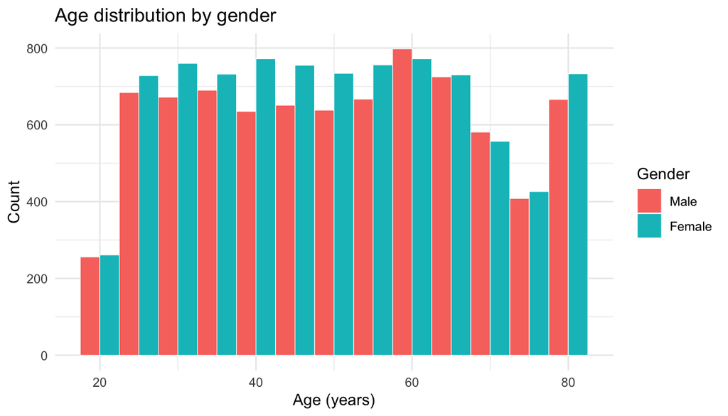

```r
fig_age_gender <- ggplot(nhanes, aes(x = age_years, fill = gender)) +
  geom_histogram(binwidth = 5, position = "dodge",
                 colour = "white", linewidth = 0.2) +
  labs(
    title = "Age distribution by gender",
    x = "Age (years)",
    y = "Count",
    fill = "Gender"
  ) +
  theme_minimal(base_size = 11)

fig_age_gender
```

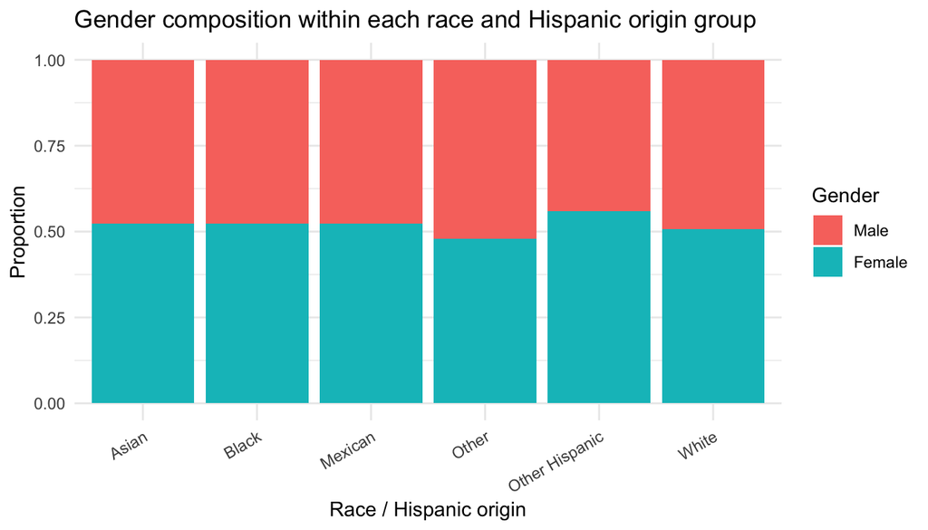

```r
fig_eth_gender <- ggplot(nhanes, aes(x = race_eth_3, fill = gender)) +
  geom_bar(position = "fill") +
  labs(
    title = paste0("Gender composition within each race and ",
                   "Hispanic origin group"),
    x = "Race / Hispanic origin",
    y = "Proportion",
    fill = "Gender"
  ) +
  theme_minimal(base_size = 11) +
  theme(axis.text.x = element_text(angle = 30, hjust = 1))

fig_eth_gender
```

### 1.1.2 Combined figures

**With cowplot**

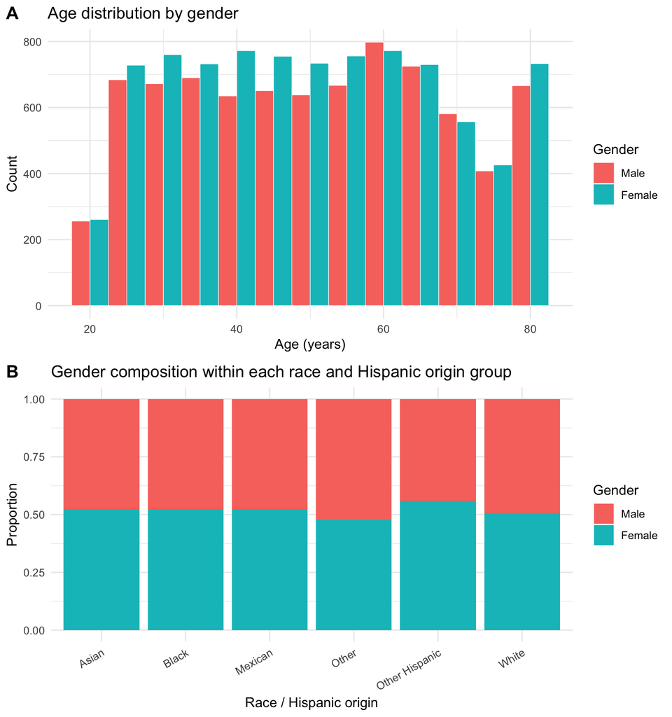

```r
plot_grid(fig_age_gender, fig_eth_gender,
          ncol = 1, labels = c("A", "B"))
```

**With ggpubr**

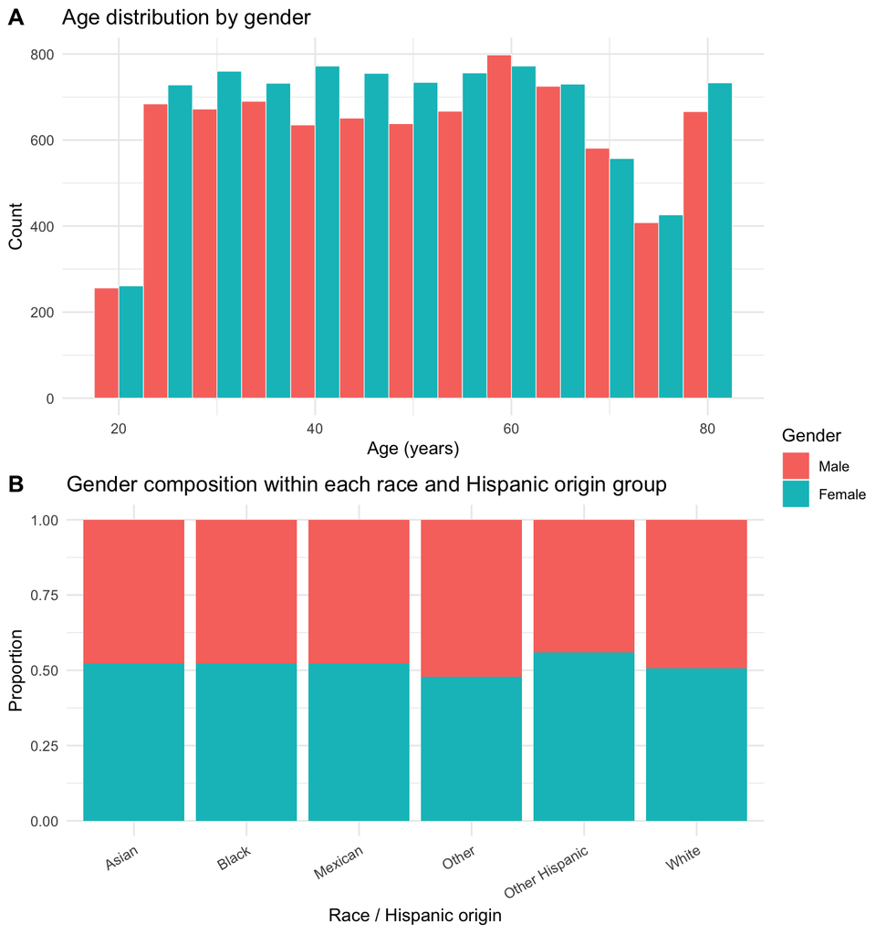

```r
ggarrange(fig_age_gender, fig_eth_gender,
          ncol = 1, labels = c("A", "B"),
          common.legend = TRUE, legend = "right")
```

## 1.2 Comparing the two layout functions

**How the two functions differ** plot_grid() and ggarrange() stack the two panels in the same way and align them identically, but they differ in how they handle the legend. plot_grid() keeps each plot as an independent object, so the identical gender legend is drawn twice, once beside each panel. ggarrange() accepts common.legend = TRUE: it extracts the shared legend, draws it once, and returns the freed horizontal space to both panels, which become slightly wider.

**Which layout works better here** For these two plots, ggarrange() gives the better layout. The gender legend is the same in both panels, so drawing it twice adds nothing and reduces the available plot width. The one drawback is that the single legend is centred vertically across the entire figure, so it sits in the gap between the panels rather than next to either one. plot_grid() would be the better choice if the two panels had different legends, since it makes no assumption that they can be merged.

# 2 Exercise 2 - Visualizing key characteristics

```r
datatable(
  nhanes,
  rownames = FALSE,
  filter   = "top",
  caption  = "Cleaned NHANES sample, adults aged 21 years and over.",
  options  = list(pageLength = 10, scrollX = TRUE)
)
```

| participant_id | bp_comment | sbp_1 | dbp_1 | sbp_2 | dbp_2 | sbp_3 | dbp_3 | sbp_4 | dbp_4 | wave_id | gender | age_years | race_eth_1 | race_eth_3 | education | marital_status | family_size | family_income | age_group |
| --- | --- | --- | --- | --- | --- | --- | --- | --- | --- | --- | --- | --- | --- | --- | --- | --- | --- | --- | --- |
| 73557 |  | 122 | 72 | 114 | 76 | 102 | 74 |  |  | 2015 | Male | 69 | Black | Black | High School | Separated | 3 | $15,000 - $19,999 | 60+ |
| 73558 |  | 156 | 62 | 160 | 80 | 156 | 42 |  |  | 2015 | Male | 54 | White | White | High School | Married | 4 | $35,000 - $44,999 | 40-59 |
| 73559 |  | 140 | 90 | 140 | 76 | 146 | 80 |  |  | 2015 | Male | 72 | White | White | Some college | Married | 2 | $65,000 - $74,999 | 60+ |
| 73561 |  | 136 | 86 | 134 | 88 | 142 | 86 |  |  | 2015 | Female | 73 | White | White | College graduate | Married | 2 | $100,000 or more | 60+ |
| 73562 |  | 160 | 84 | 158 | 82 | 154 | 80 |  |  | 2015 | Male | 56 | Mexican | Mexican | Some college | Divorced | 1 | $55,000 - $64,999 | 40-59 |
| 73564 |  | 118 | 80 | 124 | 80 | 126 | 82 |  |  | 2015 | Female | 61 | White | White | College graduate | Widowed | 1 | $65,000 - $74,999 | 60+ |
| 73566 |  | 128 | 74 | 124 | 72 | 114 | 72 |  |  | 2015 | Female | 56 | White | White | High School | Divorced | 7 or more | $15,000 - $19,999 | 40-59 |
| 73567 |  | 140 | 78 | 142 | 78 | 142 | 76 |  |  | 2015 | Male | 65 | White | White | 9-11th grade | Widowed | 1 | $10,000 - $14,999 | 60+ |
| 73568 |  | 106 | 60 | 100 | 62 | 108 | 66 |  |  | 2015 | Female | 26 | White | White | College graduate | Never married | 3 | $100,000 or more | 25-39 |
| 73571 |  | 124 | 68 |  |  | 128 | 68 | 128 | 64 | 2015 | Male | 76 | White | White | College graduate | Married | 2 | $75,000 - $99,999 | 60+ |

[output cut: 16777 more lines]

## 2.1 Age

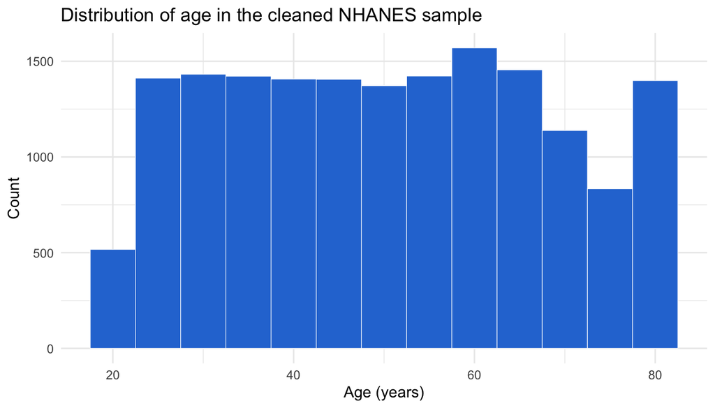

```r
p_age <- ggplot(nhanes, aes(x = age_years)) +
  geom_histogram(binwidth = 5, fill = "#2a78d6",
                 colour = "white", linewidth = 0.2) +
  labs(
    title = "Distribution of age in the cleaned NHANES sample",
    x = "Age (years)",
    y = "Count"
  ) +
  theme_minimal(base_size = 11)

p_age
```

```r
sum(is.na(nhanes$age_years))
```

```
#> [1] 0
```

```r
summary(nhanes$age_years)
```

```
#>    Min. 1st Qu.  Median    Mean 3rd Qu.    Max.
#>   21.00   35.00   51.00   50.52   64.00   80.00
```

Age ranges from 21 to 80 years with no missing values, with a median of 51 and an interquartile range of 35 to 64. The distribution is relatively flat across adulthood, with most five-year bins holding between 1,370 and 1,570 participants. Two features stand out. The first bin is much shorter, at 517 participants, because the age restriction leaves it spanning only ages 21 and 22 rather than a full five years. Counts then fall through the seventies, down to 834 in the bin covering ages 73 to 77, before the final bin rises back to roughly 1,400. That rebound is an artefact of top-coding: everyone aged 80 and over is recorded as 80 and pooled into a single value.

## 2.2 Gender

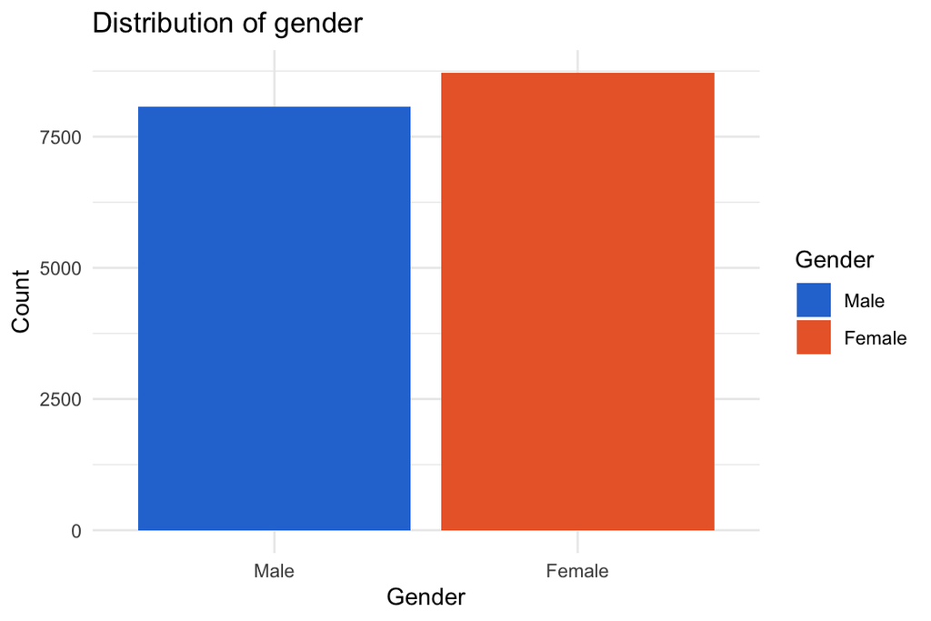

```r
p_gender <- ggplot(nhanes, aes(x = gender, fill = gender)) +
  geom_bar() +
  scale_fill_manual(values = c(Male = "#2a78d6", Female = "#eb6834")) +
  labs(
    title = "Distribution of gender",
    x = "Gender",
    y = "Count",
    fill = "Gender"
  ) +
  theme_minimal(base_size = 11)

p_gender
```

```r
table(nhanes$gender, useNA = "ifany")
```

```
#>
#>   Male Female
#>   8071   8716
```

Gender has no missing values. The sample is close to balanced but not exactly even: 8,716 women and 8,071 men, corresponding to 51.9% and 48.1%, respectively, a difference of 645 participants.

## 2.3 The two race and Hispanic origin variables

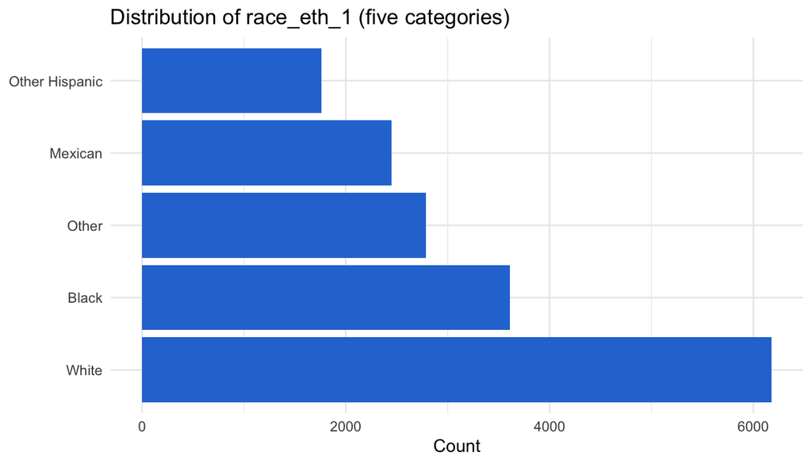

```r
p_eth1 <- ggplot(nhanes, aes(y = fct_infreq(race_eth_1))) +
  geom_bar(fill = "#2a78d6") +
  labs(
    title = "Distribution of race_eth_1 (five categories)",
    x = "Count",
    y = NULL
  ) +
  theme_minimal(base_size = 11)

p_eth1
```

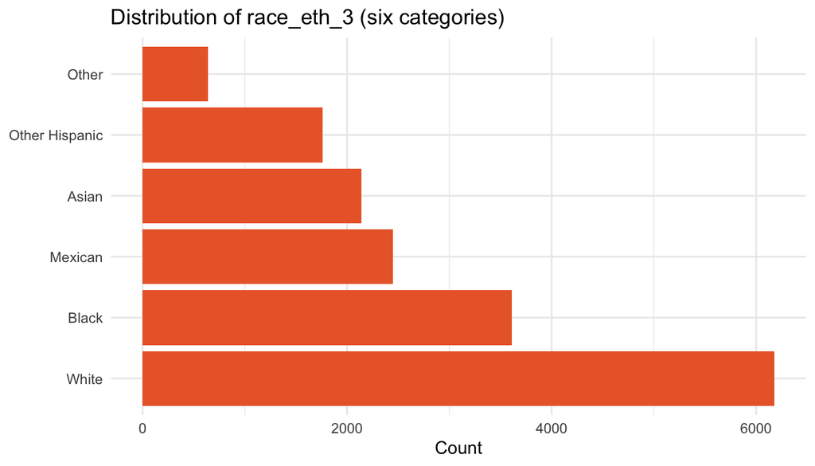

```r
p_eth3 <- ggplot(nhanes, aes(y = fct_infreq(race_eth_3))) +
  geom_bar(fill = "#eb6834") +
  labs(
    title = "Distribution of race_eth_3 (six categories)",
    x = "Count",
    y = NULL
  ) +
  theme_minimal(base_size = 11)

p_eth3
```

```r
table(nhanes$race_eth_1, useNA = "ifany")
```

```
#>
#>          Black        Mexican          Other Other Hispanic
#>           3609           2450           2785           1763
#>          White
#>           6180
```

```r
table(nhanes$race_eth_3, useNA = "ifany")
```

```
#>
#>          Asian          Black        Mexican          Other
#>           2143           3609           2450            642
#> Other Hispanic          White
#>           1763           6180
```

**Both variables are complete** Neither variable has missing values. The largest group in both is White, with 6,180 participants (36.8%), followed by Black with 3,609 (21.5%).

**Choosing between the two** The two variables describe the same participants at two levels of detail. race_eth_3 adds one category, Asian, with 2,143 participants, and the tables show exactly where it came from: Other falls from 2,785 to 642, a difference of 2,143. Every other category is unchanged. race_eth_3 is therefore the variable to keep, since it separates a group that race_eth_1 hides inside a residual category while losing no information.

```r
fig_dir <- here("figures")
dir.create(fig_dir, showWarnings = FALSE)

ggsave(file.path(fig_dir, "ex2_age.png"), p_age,
       width = 7, height = 4, dpi = 300, bg = "white")
ggsave(file.path(fig_dir, "ex2_gender.png"), p_gender,
       width = 6, height = 4, dpi = 300, bg = "white")
ggsave(file.path(fig_dir, "ex2_eth1.png"), p_eth1,
       width = 7, height = 4, dpi = 300, bg = "white")
ggsave(file.path(fig_dir, "ex2_eth3.png"), p_eth3,
       width = 7, height = 4, dpi = 300, bg = "white")
```

```r
nhanes <- nhanes |>
  select(-race_eth_1)

ncol(nhanes)
```

```
#> [1] 19
```

# 3 Exercise 3 - Improving a ggplot figure

## 3.1 Points that need improvement + how I will improve it

**The figure answers the wrong question** The goal is to show change relative to each participant’s baseline, but the y-axis shows absolute weight. Starting weights range from 64.3 to 99.4 kg, so the reader must mentally subtract each participant’s starting value to see the change. Lines can also cross for reasons unrelated to the diet: someone losing 19 kg from 95 kg still ends above someone gaining 4 kg from 65 kg.

**The colour legend carries no information** Participant is an identifier, not a measured quantity, yet it is mapped to a colour scale that implies an ordering. Twenty colours are also difficult to match to twenty lines, while the legend takes up a quarter of the figure for little benefit. The y-axis has no units, and the figure has no title.

**How I will improve it** Plot change from baseline with a reference line at zero, so all participants start at the same point and the quantity of interest can be read directly from the axis. Replace the 20-colour scale with three outcome categories that can be matched to a legend and highlight the relevant structure. Add units, a title, and a light theme.

## 3.2 Improved figure

```r
diet <- import(here("data", "diet.csv"))

diet <- diet |>
  rename(week = Week, participant = Participant, weight = Weight) |>
  group_by(participant) |>
  mutate(
    change       = weight - weight[week == 0],
    final_change = change[week == max(week)]
  ) |>
  ungroup() |>
  mutate(
    participant = factor(participant),
    outcome = factor(
      case_when(
        final_change < -1 ~ "Lost weight",
        final_change >  1 ~ "Gained weight",
        TRUE              ~ "No change"
      ),
      levels = c("Lost weight", "No change", "Gained weight")
    )
  )

dim(diet)
```

```
#> [1] 340   6
```

```r
table(diet$outcome) / 17
```

```
#>
#>   Lost weight     No change Gained weight
#>            10             5             5
```

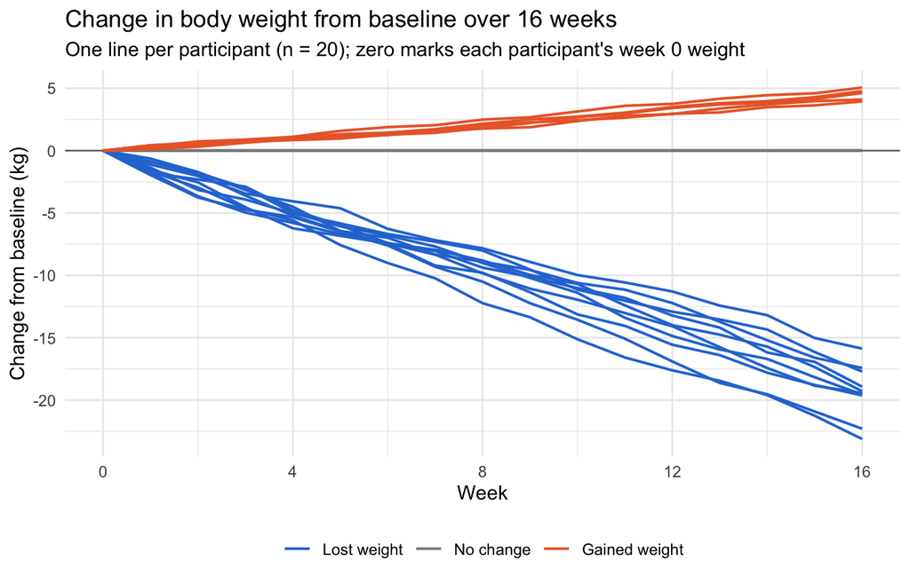

```r
fig_diet <- ggplot(diet, aes(x = week, y = change,
                             group = participant, colour = outcome)) +
  geom_hline(yintercept = 0, linewidth = 0.4, colour = "grey40") +
  geom_line(linewidth = 0.7) +
  scale_colour_manual(values = c("Lost weight"   = "#2a78d6",
                                 "No change"     = "#8a8a8a",
                                 "Gained weight" = "#eb6834")) +
  scale_x_continuous(breaks = seq(0, 16, 4)) +
  labs(
    title = "Change in body weight from baseline over 16 weeks",
    subtitle = paste0("One line per participant (n = 20); zero marks ",
                      "each participant's week 0 weight"),
    x = "Week",
    y = "Change from baseline (kg)",
    colour = NULL
  ) +
  theme_minimal(base_size = 11) +
  theme(legend.position = "bottom")

fig_diet
```

Plotted this way, the sample separates into three groups that the original figure did not reveal: ten participants end 15.9 to 23.1 kg below baseline, five remain at their starting weight, and five gain 3.9 to 5.1 kg. The diet did not produce a uniform effect, which the original figure could not show.

# 4 Exercise 4 - Exploring relationships through visualizations

## 4.1 Building the analysis sample

```r
# Average of the four systolic readings.
# NA only when all four readings are missing.
nhanes <- nhanes |>
  rowwise() |>
  mutate(
    sbp_avg = if (all(is.na(c(sbp_1, sbp_2, sbp_3, sbp_4)))) {
      NA_real_
    } else {
      mean(c(sbp_1, sbp_2, sbp_3, sbp_4), na.rm = TRUE)
    }
  ) |>
  ungroup()

sum(is.na(nhanes$sbp_avg))
```

```
#> [1] 1334
```

```r
analysis <- nhanes |>
  filter(!is.na(age_years), !is.na(gender), !is.na(sbp_avg))

nrow(nhanes)
```

```
#> [1] 16787
```

```r
nrow(analysis)
```

```
#> [1] 15453
```

```r
analysis <- analysis |>
  mutate(
    bp_category = factor(
      case_when(
        sbp_avg <  120 ~ "Normal",
        sbp_avg <  130 ~ "Elevated",
        sbp_avg <  140 ~ "Stage 1 hypertension",
        TRUE           ~ "Stage 2 hypertension"
      ),
      levels = c("Normal", "Elevated",
                 "Stage 1 hypertension", "Stage 2 hypertension")
    )
  )

table(analysis$bp_category)
```

```
#>
#>               Normal             Elevated Stage 1 hypertension
#>                 6716                 3384                 2391
#> Stage 2 hypertension
#>                 2962
```

**From 16,787 to 15,453 participants** Averaging the four systolic blood pressure readings yields a single value for each participant. Participants were considered missing only if all four readings were unavailable, allowing inclusion of anyone with at least one valid measurement. Requiring nonmissing data for age, gender, and mean systolic blood pressure reduced the sample from 16,787 to 15,453 participants, a loss of 1,334 (7.9%). Because age and gender were complete in the cleaned dataset, all exclusions were due to missing blood pressure measurements.

**The loss is evenly spread** Each age group lost between 7% and 9% of its participants, and the gender distribution remained balanced, with 7,450 men and 8,003 women. Restricting the analysis to participants with complete blood pressure data therefore had little impact on the sample composition and did not alter its age structure, an important consideration given the strong association between age and blood pressure.

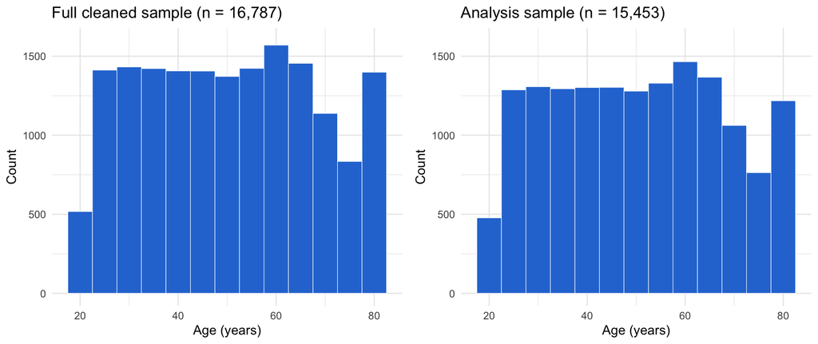

```r
# Reuse p_age from Exercise 2, swapping in the analysis sample with %+%
p_age_full <- p_age +
  labs(title = "Full cleaned sample (n = 16,787)") +
  coord_cartesian(ylim = c(0, 1600))

p_age_analysis <- p_age %+% analysis +
  labs(title = "Analysis sample (n = 15,453)") +
  coord_cartesian(ylim = c(0, 1600))

plot_grid(p_age_full, p_age_analysis, nrow = 1)
```

**The age distribution barely moves** Reusing the age histogram from the previous exercise, the two panels have the same shape, including the dip in the bin covering ages 73 to 77 and the rise in the top-coded bin. Most bins lose between 6% and 9% of their participants. One exception is worth noting: the top-coded bin loses 12.9%, roughly twice the rate of the middle bins, so missing blood pressure readings are somewhat more common among the oldest participants. Apart from that group, the analysis sample retains the age structure of the cleaned dataset.

## 4.2 How blood pressure is distributed

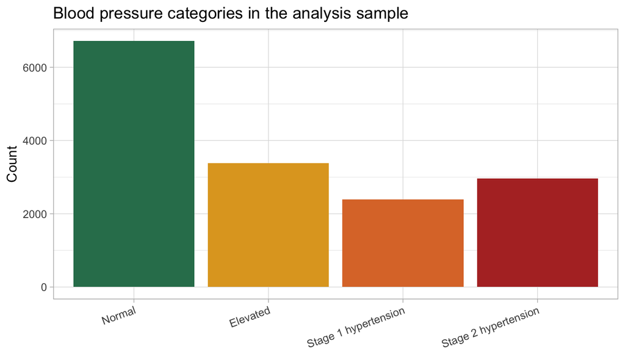

```r
bp_cols <- c(
  "Normal"               = "#2E7D5B",
  "Elevated"             = "#E0A526",
  "Stage 1 hypertension" = "#DD7734",
  "Stage 2 hypertension" = "#B3322C"
)

ggplot(analysis, aes(x = bp_category, fill = bp_category)) +
  geom_bar() +
  scale_fill_manual(values = bp_cols) +
  labs(
    title = "Blood pressure categories in the analysis sample",
    x = NULL,
    y = "Count"
  ) +
  theme_light(base_size = 11) +
  theme(legend.position = "none",
        axis.text.x = element_text(angle = 20, hjust = 1))
```

Almost half of the sample falls within the normal blood pressure range, with 6,716 participants (43.5%). The remaining 56.5% is divided among elevated blood pressure (3,384, 21.9%), stage 1 hypertension (2,391, 15.5%), and stage 2 hypertension (2,962, 19.2%). Overall, about one third of adults in the analysis sample meet a criterion for hypertension.

## 4.3 Age, gender and blood pressure

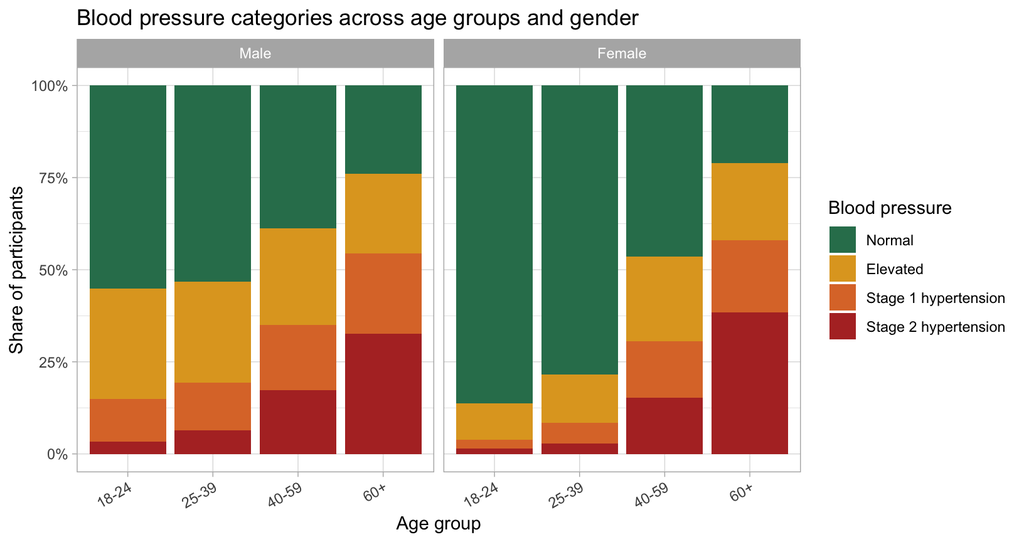

```r
ggplot(analysis, aes(x = age_group, fill = bp_category)) +
  geom_bar(position = "fill") +
  facet_wrap(~ gender) +
  scale_fill_manual(values = bp_cols) +
  scale_y_continuous(labels = percent) +
  labs(
    title = "Blood pressure categories across age groups and gender",
    x = "Age group",
    y = "Share of participants",
    fill = "Blood pressure"
  ) +
  theme_light(base_size = 11) +
  theme(axis.text.x = element_text(angle = 30, hjust = 1))
```

**Age is the dominant factor** Among the youngest participants, 86.3% of women and 55.1% of men are in the normal range, while stage 2 hypertension is rare (1.4% and 3.3%). By age 60 and over, the share in the normal range has fallen to roughly one in five in both groups (21.1% of women, 23.9% of men), while stage 2 hypertension reaches 38.4% and 32.7%. Gender differences are most apparent at younger ages, when women have a higher proportion in the normal range; by age 60 and over, the difference reverses for stage 2 hypertension, with a higher proportion among women.

**A note on the color palette** The palette follows a green to red progression that reinforces increasing severity, though this pairing is less accessible to readers with red-green colour vision deficiency; the ordered stacking preserves the sequence independently of colour.